# L'NBA, analisi del gioco nel corso degli anni

## Perchè ho scelto questo argomento?

- passione per il basket
- curiosità sull'evoluzione del gioco
- recente conclusione della stagione

## Domande che hanno guidato l'analisi

DOMANDE:

1. come sono variate le statistiche cestistiche nel corso degli anni?
2. il tiro da 3 punti ha cambiato il gioco?
3. la fisicità nelle partite è scesa per dare spazio allo spettacolo?
4. esiste una statistica che permette di anticipare chi vincera?

# NBA stats dataset

- dove è stato trovato : [kaggle](https://www.kaggle.com/datasets/sumitrodatta/nba-aba-baa-stats), dove i dati sono aggiornati all'ultima stagione 2023/2024
- disponibile anche un'API ufficiale, qui un riferimento ad un [tutorial](https://github.com/swar/nba_api)
- contiene statistiche base e avanzate di squadre e giocatori nella regular season, i playoffs non sono contenuti nel dataset

# Com'è cambiato il gioco nel corso dei più di 70 anni di storia?

## come sono cambiate le statistiche principali ?

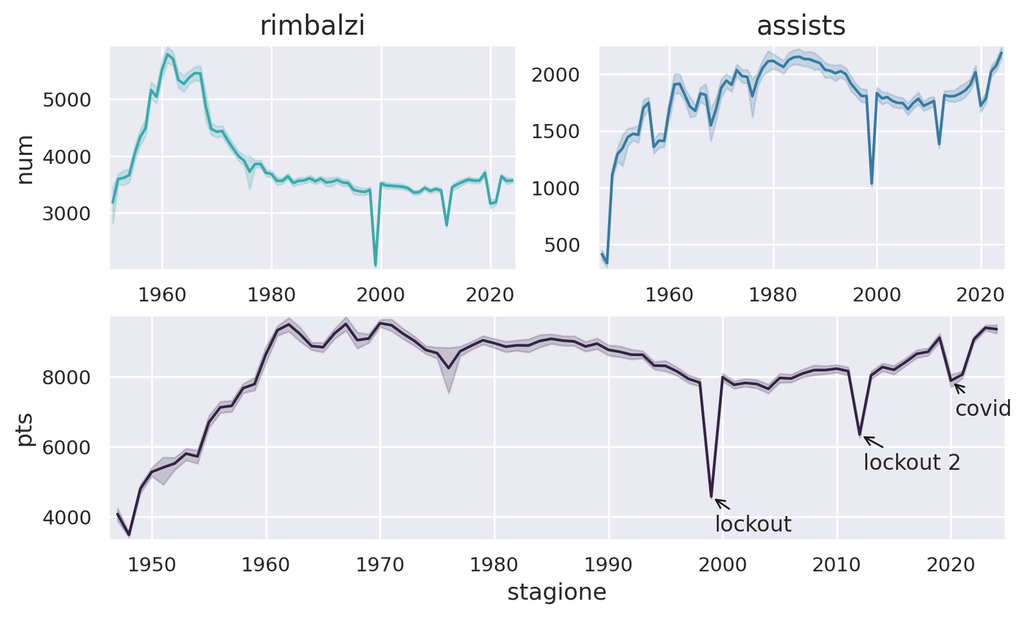

# Il tiro da 3 punti ha cambiato il gioco ?

## sguardo ai cambiamenti dopo l'introduzione del tiro da 3 punti

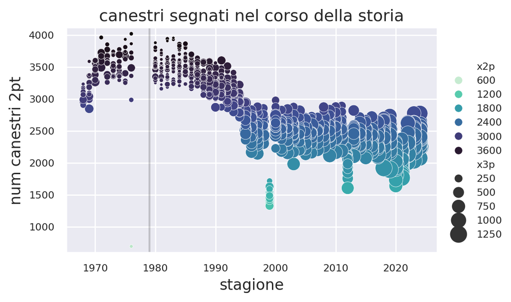

## Il tiro da 3 punti è più efficacie del tiro da 2 punti?

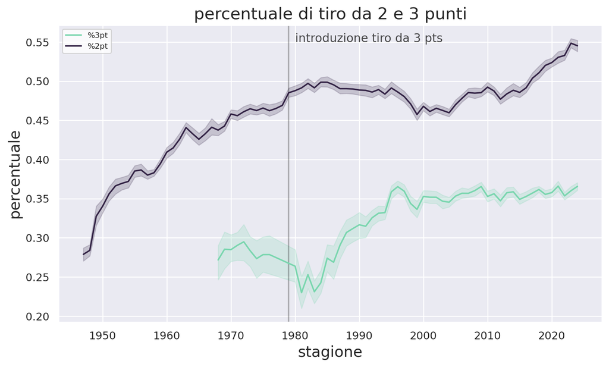

# La fisicità è stata abbandonata per dare spazio allo spettacolo?

## il defensive rating

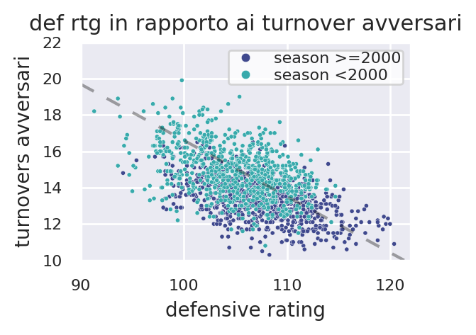

pearson: -0.5288414072318302

# Esiste una statistica che permetta di anticipare il risultato di una partita?

## il true shooting percent e l'effective field goal percent

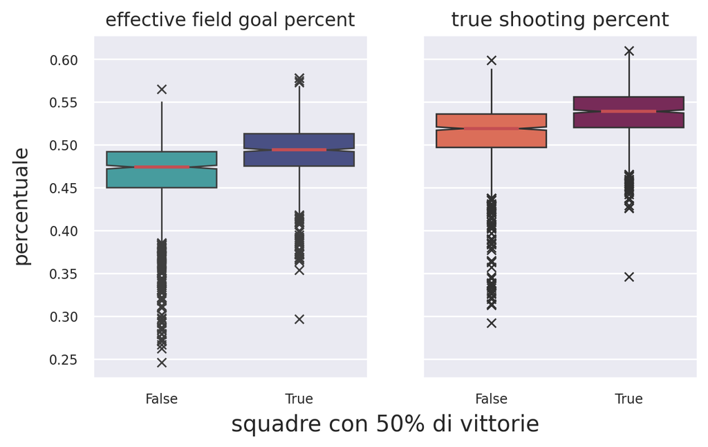

# Conclusioni

1. il tiro da 3 punti ha dato un'alternativa offensiva, facendo diminuire la mole del tiro classico e rendendolo allo stesso tempo sempre più efficacie
2. la fisicità è stata effettivamente abbandonata per dare spazio allo spettacolo
3. ci sono delle statistiche che possono guidarci verso le squadre che vinceranno con più probabilità ma la certezza della vittoria di una squadra rispetto ad un'altra è impossibile